# Math 243 Final Project

Dean, Hans, and Laura

## Introduction

Based off of data collected by a Psychology Today survey in the late 60s, we are modeling the frequency of extramarital affairs across 601 married individuals. We use tree-based methods to determine the most important variables and to establish a predictive model. We finally compare our results to those found in a 1978 paper written on the same dataset that utilizes a tobit modeling method, common in many econometric studies.

## The Data

- How often engaged in extramarital sexual intercourse during the past year: ordinal, “nbaffairs”
- Sex: categorical, “sex”
- Age: ordinal, “age”
- Number of years married: ordinal, “ym”
- Children: categorical, “child”
- How religious: ordinal, “religious”
- Level of education: ordinal, “education”
- Occupation: ordinal, “occupation”
- Happiness rating of marriage: ordinal, “rate”

Our data is based on a 1978 paper called âA Theory of Extramarital Affairsâ which we downloaded through R’s econometrics package. The data was collected through a magazine survey published in Psychology Today about a decade before the paper was published. There at 601 observations, each being a married individual. Our dependent variable is an ordinal measure of “how often engaged in extramarital sexual intercourse during the past year,” which is measured on a scale from 0-12, 0 meaning none and 12 meaning either monthly, weekly, or daily. This variable was collected as continuous but compressed into an ordinal variable by the author of the paper for whatever reason. There are eight explanatory variables, 2 of which are binary and 6 which are ordinal. The binary explanatory variables are sex and whether or not the individual has children. The ordinal explanatory variables are age, number of years married, a measure of how religious they are, education level, occupation, and a rating of the happiness of their marriage. Once again, age and number of years married were measured as continuous but compressed as an ordinal variable by the author of the paper.

## Exploratory Data Analysis

We plotted several of our variables to get an idea of the makeup of the dataset and the spread of our variables.

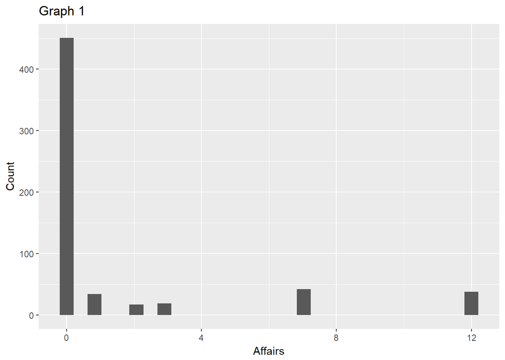

“Graph 1” is a histogram of the spread of the affairs variable. As you can see, a majority of individuals in the dataset did not engage in an affair.

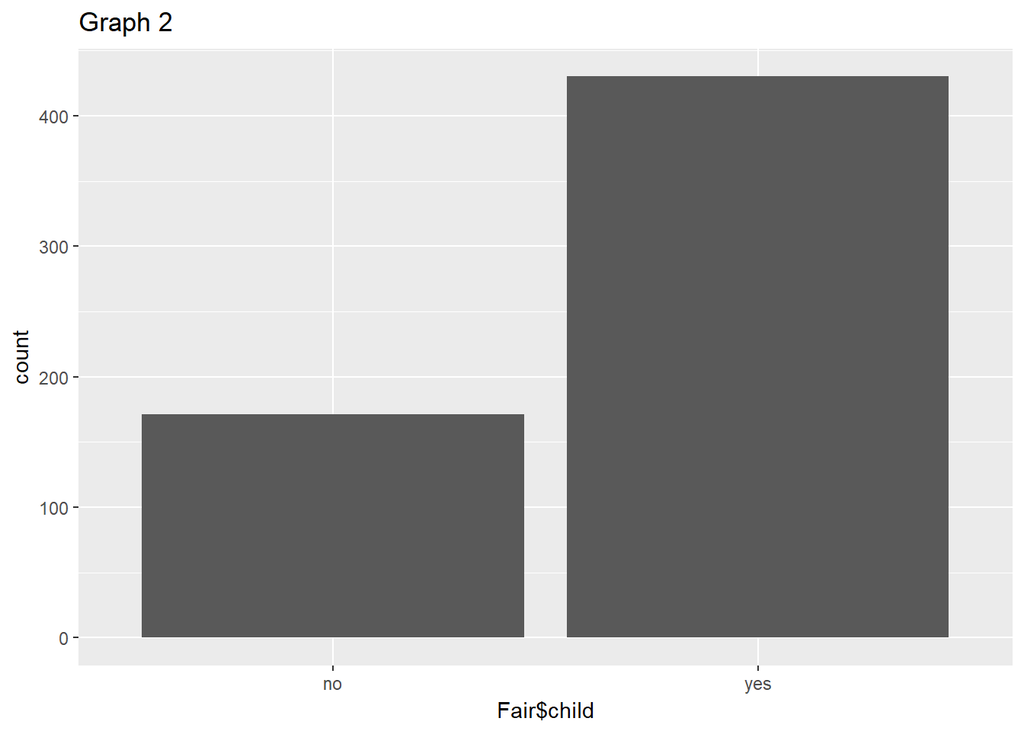

“Graph 2” displays the children variable of the dataset, showing that most individuals did have children.

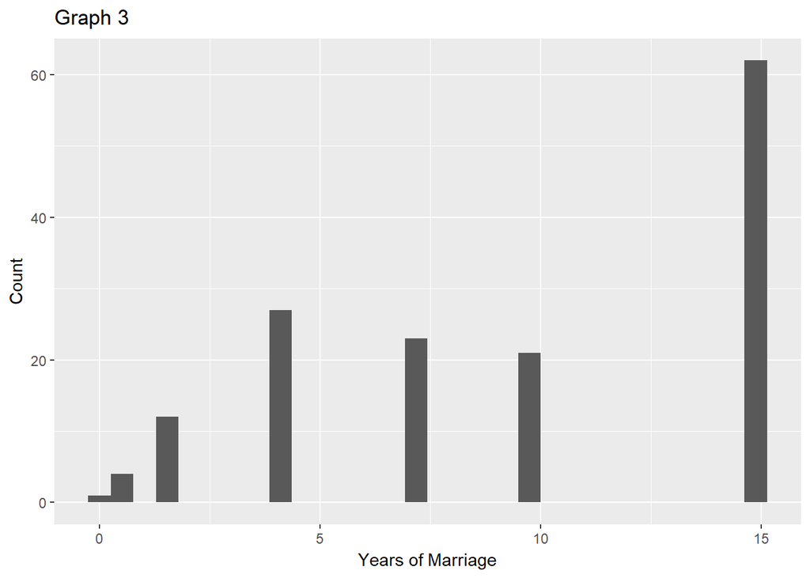

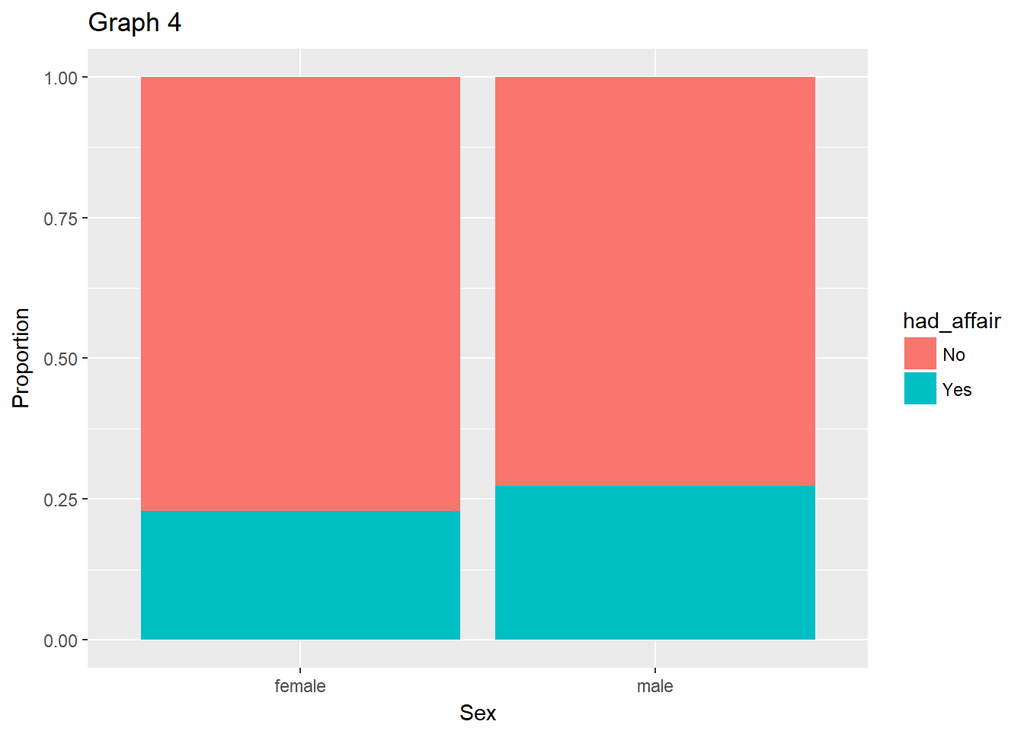

“Graph 4” breaks the sex variable into two groups: those who had an affair and those who did not. It appears that this dataset represents men who cheat and women who cheat about equally.

## Modeling

```
##
## Call:
## tobit(formula = nbaffairs ~ ., left = 0, data = Fair_train)
##
## Observations:
##          Total  Left-censored     Uncensored Right-censored
##            450            337            113              0
##
## Coefficients:
##             Estimate Std. Error z value Pr(>|z|)
## (Intercept)  4.35548    4.45515   0.978  0.32826
## sexmale      0.58526    1.24526   0.470  0.63836
## age         -0.11667    0.09074  -1.286  0.19851
## ym           0.42387    0.17017   2.491  0.01274 *
## childyes     0.83560    1.48422   0.563  0.57344
## religious   -1.43050    0.45042  -3.176  0.00149 **
## education    0.18142    0.26136   0.694  0.48759
## occupation   0.04747    0.37262   0.127  0.89863
## rate        -2.42771    0.48575  -4.998  5.8e-07 ***
## Log(scale)   2.10670    0.07733  27.244  < 2e-16 ***
## ---
## Signif. codes:  0 '***' 0.001 '**' 0.01 '*' 0.05 '.' 0.1 ' ' 1
##
## Scale: 8.221
##
## Gaussian distribution
## Number of Newton-Raphson Iterations: 4
## Log-likelihood: -530.1 on 10 Df
## Wald-statistic: 46.82 on 8 Df, p-value: 1.6605e-07
```

```
##
## Call:
## glm(formula = had_affair ~ ., family = "binomial", data = b_Fair_train)
##
## Deviance Residuals:
##     Min       1Q   Median       3Q      Max
## -1.5495  -0.7682  -0.5653   0.5618   2.4422
##
## Coefficients:
##              Estimate Std. Error z value Pr(>|z|)
## (Intercept)  0.773344   1.008568   0.767  0.44322
## sexmale      0.144622   0.279395   0.518  0.60472
## age         -0.028972   0.020659  -1.402  0.16081
## ym           0.070216   0.037678   1.864  0.06238 .
## childyes     0.444041   0.341712   1.299  0.19379
## religious   -0.272592   0.100843  -2.703  0.00687 **
## education    0.053874   0.057990   0.929  0.35288
## occupation   0.001723   0.082952   0.021  0.98343
## rate        -0.522688   0.106564  -4.905 9.35e-07 ***
## ---
## Signif. codes:  0 '***' 0.001 '**' 0.01 '*' 0.05 '.' 0.1 ' ' 1
##
## (Dispersion parameter for binomial family taken to be 1)
##
##     Null deviance: 507.20  on 449  degrees of freedom
## Residual deviance: 459.09  on 441  degrees of freedom
## AIC: 477.09
##
## Number of Fisher Scoring iterations: 4
```

```
##
## log_pred  No Yes
##      No  108  30
##      Yes   6   7
```

Recall that Fair decomposed the continuous variable of number of affairs to the ordinal `nbaffairs`. This makes interpretation of the model slightly more difficult. To allow for better interpretation and also robustness check, we converted `nbaffairs` to `had_affair` which is a binary indicator of whether or not someone cheated. A logistic regression was used to establish a baseline. The confusion matrix is above and the test missclassifcation rate is 0.2384106. A naive predictor that predicts no one cheats has a test missclassfication rate of 0.2450331. Our logistic model does slightly better.

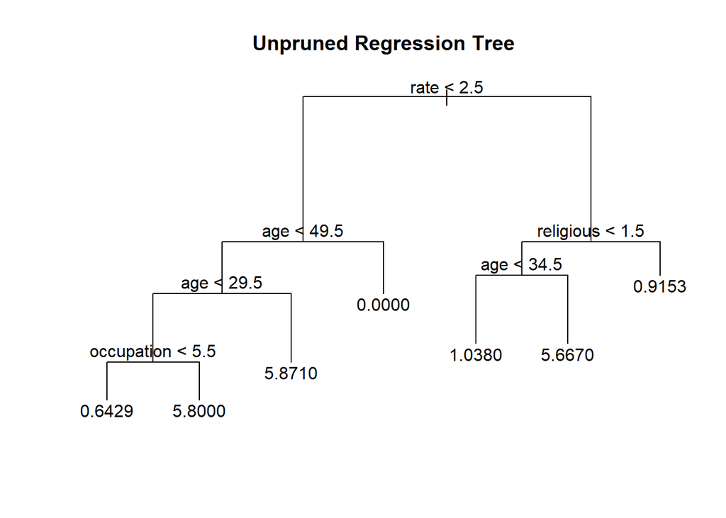

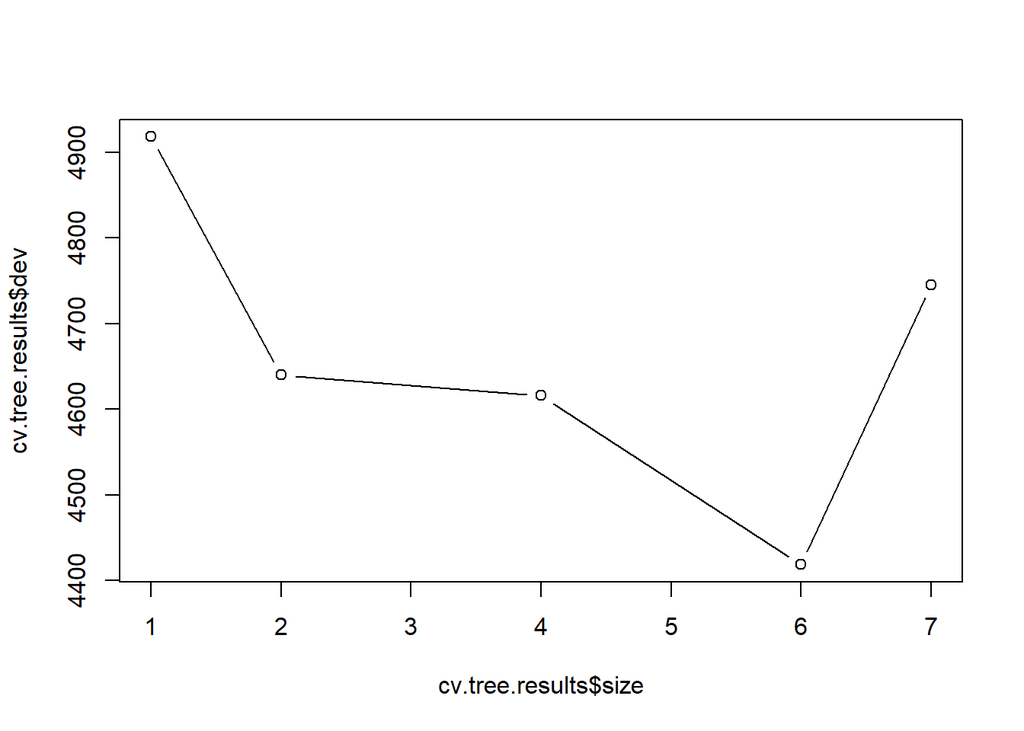

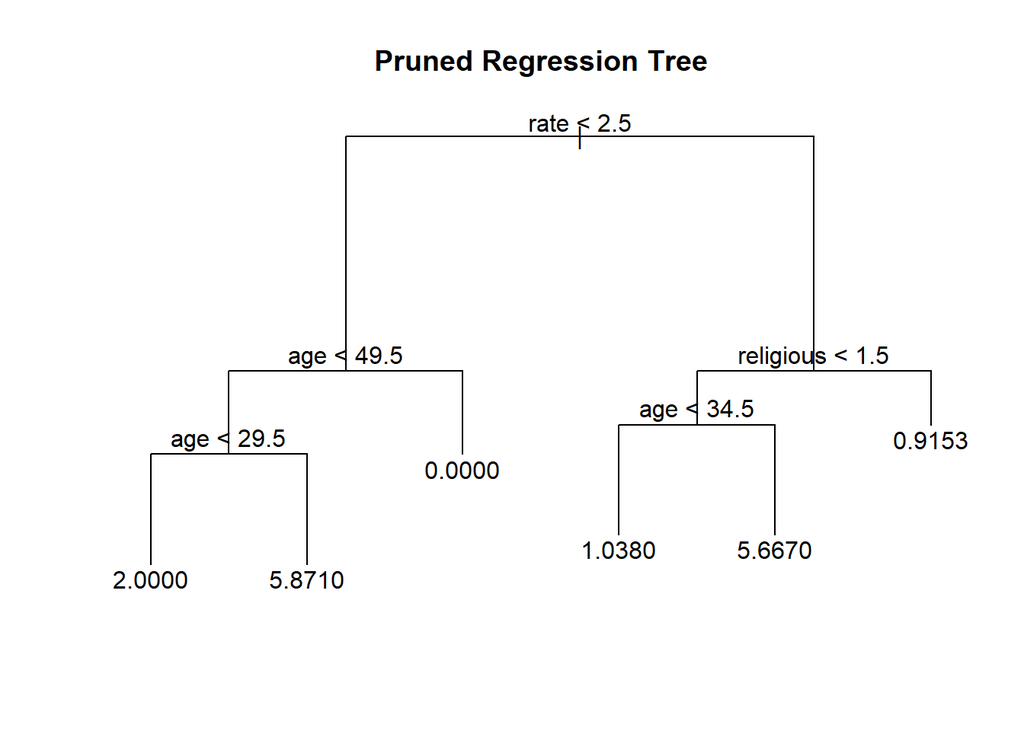

We fit a regression tree to the data. Given that our sample size is not large (450), the tree does not have many splits and is not too complex. However, just in case, we applied tree pruning and found that the best size of the tree is 6 based on deviance. This is not much smaller than the original tree, which explains why the test MSEs between the unpruned and the pruned tree is not very different: 9.5611616 versus 9.5196127. However, the pruned tree slightly outperforms the Tobit model (9.5286637).

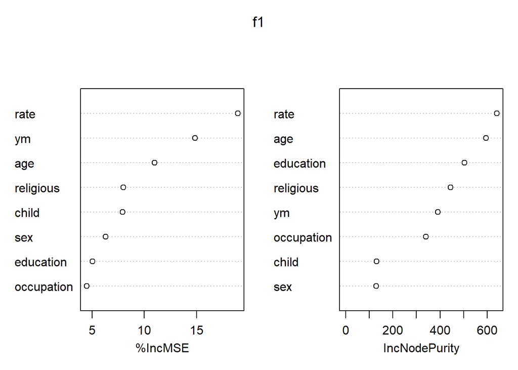

This result is odd. `education` was important for increasing nodal purity by decreasing training RSS but not important for decreasing training MSE. RSS and MSE are highly related. The likely explanation for this is that the algorithm computing best reduction in RSS is doing so myopically, that is, at each individual step it is reducing the RSS to the best of its abilities. However, in a big picture view, `education` did not reduce training MSE very well.

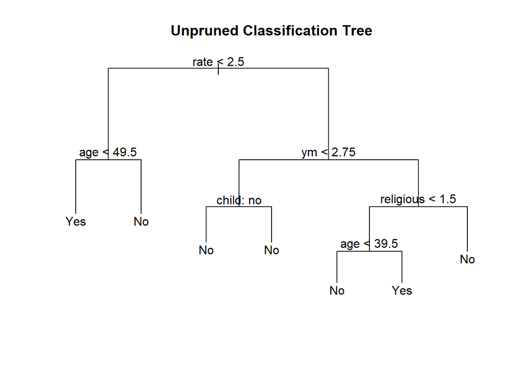

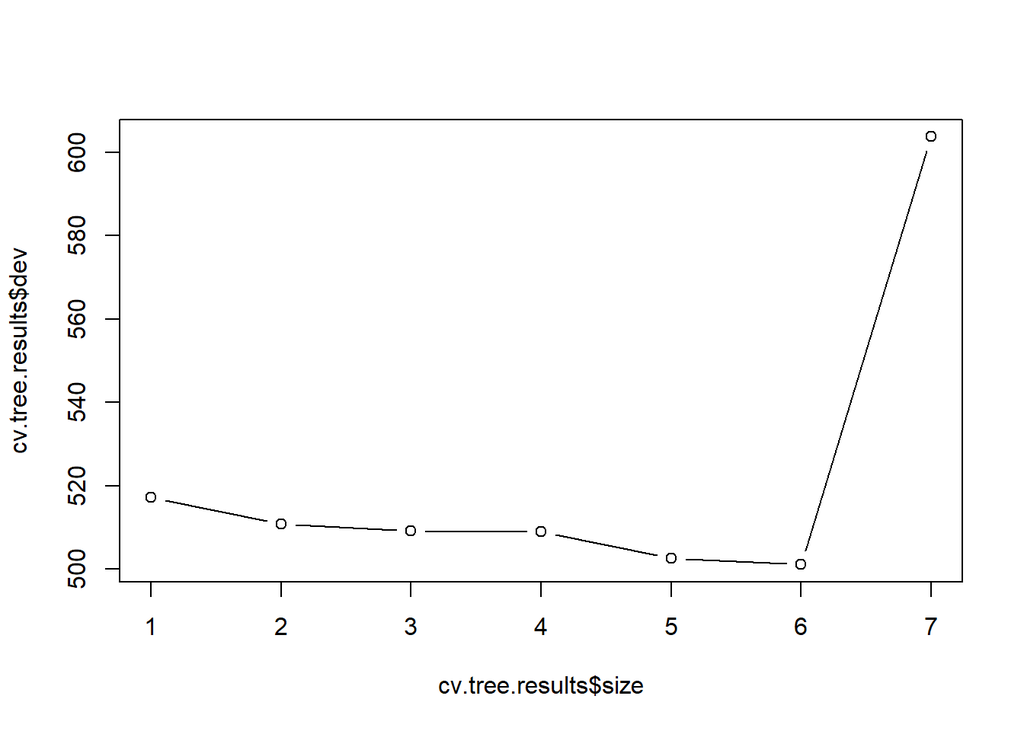

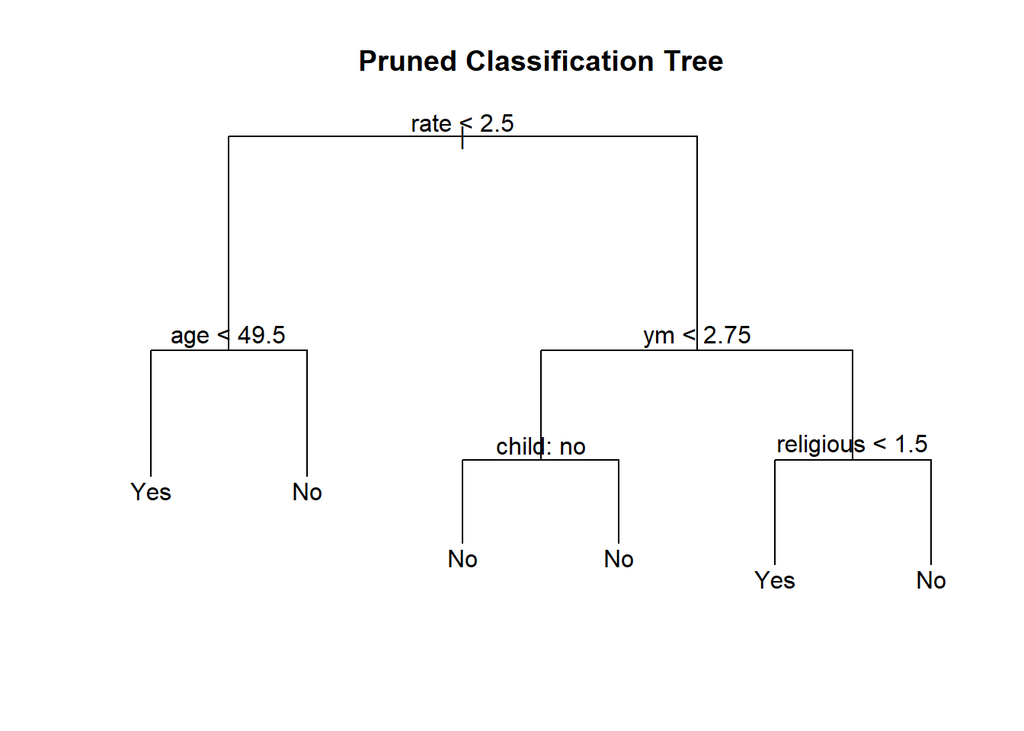

```
##
## pred  No Yes
##   No  98  26
##   Yes 16  11
```

We ran the same methods used for the continuous-ordinal version of number affairs on the binary version of affairs (`had_affair`). The confusion matrix for the pruned classification tree is above. As you can see, in comparison to the confusion matrix for the logistic regression, the prune tree model was a lot more aggressive (less conservative) in predicting infidelity. This leads to slightly increased test true positives (0.0614035 to 0.0964912) but a high increase in test false positives (0.0526316 to 0.1403509).

The test missclassification rate for the pruned tree is 0.2781457 which unfortunately is not better than the logistic regression. In fact, it does not even outperform the naive predictor which had a test missclassification rate of 0.2450331.

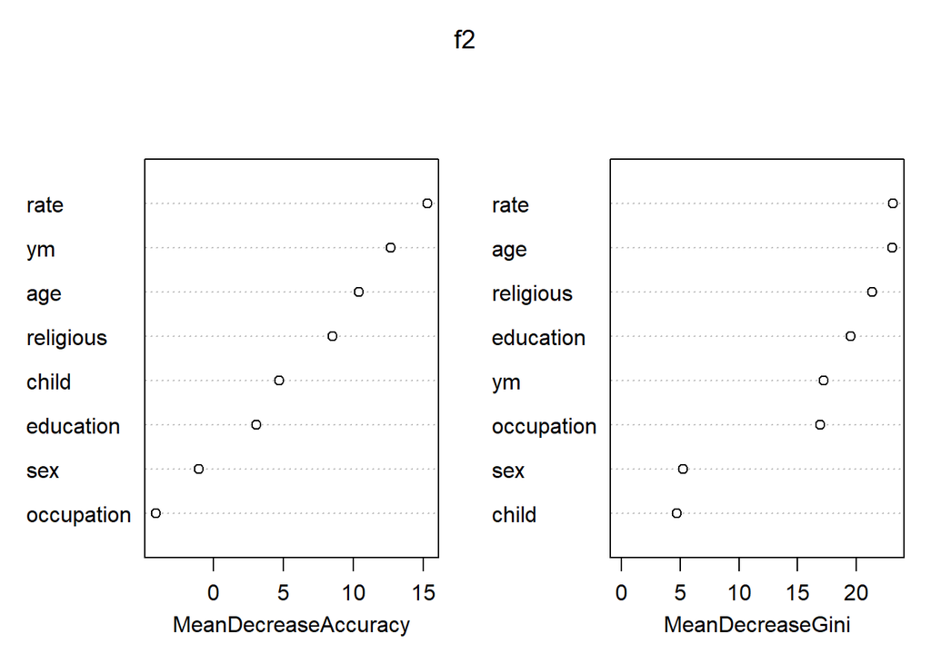

```
##
##        No Yes
##   No  106  30
##   Yes   8   7
```

The Random Forest classification model exhibited similar characteristics as the regression version. The same four variables are the most important in accurate predictions: `rate`, `ym`, `age`, and `religious`. Again, the oddity of `education` being unimportant in helping predictions but important in increasing nodal purity appears here.

For the Random Forest model the confusion matrix is extremely similar to the logistic model’s confusion matrix, meaning they were both about equally conservative and certainly more conservative than the prune tree. However, the story isn’t so happy when looking at test missclassification rates. The Random Forest test missclassification rate is 0.2516556 which although is better than the pruned tree, still underperforms both the logistic model (0.2384106) and the naive predictor (0.2450331).

The pruned tree model is being punished heavily for being overaggressive, that is, having too many false positives. But what if someone had trust issues and really wanted to catch cheaters, even at the expensive of some false positives? This person would rather an innocent spouse be accused of cheating than have a true cheater get away. For this person, false negatives are much worse than false positives. This can also be interpreted as saying the weight of classifying a true positive (a true cheater) should be higher than the weight of classifying a true negative (a true faithful partner). This can be reflected mathematically by assigning weights to each observation in the test data set and recomputing the test missclassification rate.

The new missclassification rate would be:

$$\frac{\sum_{i=1}^{N} w_{i}*IND(\hat{y_{i}} \neq y_{i})}{\sum_{i=1}^{N} w_{i}}$$

where $w_{i}$ is the weight of the ith observations and IND() is the indicator function.

In our case, $w_{i}$ for a true cheater was 3 and $w_{i}$ for a true faithful spouse was 1. When applying these weights in computing the test MSE, it is unsurprising that the pruned tree (0.4177778) outperforms both the logistic (0.4266667) and the Random Forest (0.4355556) models. This is because the pruned tree model is much more aggressive about declaring someone a cheater and thus is rewarded for catching true positives while not punishing false positives as strongly. This just shows that you can manipulate the performance ordering of models based on differing weights set on the observations, unbalancing the previously equal punishment of a false negative and a false positive.

Source: http://www.stat.cmu.edu/~ryantibs/datamining/lectures/25-boost.pdf